# Ford_GoBike-Exploratory

### INTRODUCTION

###### This project Ford GoBike dataset of Year 2019 (till July). GoBike is the Bay Area's new bike share system, with thousands of public bikes for use across the greater San Francisco Bay area. An app was also created to co-piloting for getting around town. For more information on this program, please go to https://www.fordgobike.com. Our analysis covers data from Jan 2019 to July 2019. The above mentioned Data Set focuses on information with regard to the individual rides undertaken in a bike-sharing system expanded over the greater San Francisco Bay Area. We will need to join together multiple data files. As a first step, we will import relevant libraries.

```python
%matplotlib inline

import pandas as pd
import numpy as np
import matplotlib.pyplot as plt
import matplotlib.ticker as ticker
import seaborn as sns
from mpl_toolkits import mplot3d
```

### GATHERING

###### Data has been downloaded from https://www.lyft.com/bikes/bay-wheels/system-data into 7 separate files and then concated to form a single dataset 'ford_raw'. The Features included in the Data are as follows :

- Member Year of Birth
- Member Gender
- User Type (Subscriber or Customer – “Subscriber” = Member or “Customer” = Casual)
- Trip Duration(in seconds)
- Bike ID
- Start Time and Date
- End Time and Date
- Start Station ID
- End Station ID
- Start Station Name
- End Station Name
- End Station Latitude
- End Station Longitude
- Start Station Latitude
- Start Station Longitude

```python
ford_raw0719 = pd.read_csv('E:/data/UDACITY/Project5/201907-baywheels-tripdata.csv', low_memory= False)
ford_raw0619 = pd.read_csv('E:/data/UDACITY/Project5/201906-baywheels-tripdata.csv', low_memory= False)
ford_raw0519 = pd.read_csv('E:/data/UDACITY/Project5/201905-baywheels-tripdata.csv', low_memory= False)
ford_raw0419 = pd.read_csv('E:/data/UDACITY/Project5/201904-fordgobike-tripdata.csv', low_memory= False)
ford_raw0319 = pd.read_csv('E:/data/UDACITY/Project5/201903-fordgobike-tripdata.csv', low_memory= False)
ford_raw0219 = pd.read_csv('E:/data/UDACITY/Project5/201902-fordgobike-tripdata.csv', low_memory= False)
ford_raw0119 = pd.read_csv('E:/data/UDACITY/Project5/201901-fordgobike-tripdata.csv', low_memory= False)
```

```python
ford_raw = pd.concat([ford_raw0119,ford_raw0219,ford_raw0319,ford_raw0419,ford_raw0519,ford_raw0619,ford_raw0719], ignore_index = True, sort = True);
```

### CLEANING:-

###### Before we could move to analyse our dataset, it is important to clean and wrangle the data and, make it ready for analysis. hence, we'll carry out following tasks:-

1. Make a copy of ford_raw for further analysis.
2. Convert 'start_time' and 'end_time' in time format.
3. Convert 'duration' column in minutes.
4. Drop unnecessary Columns
5. Create new column 'member_age'

###### Thus, let us first make a copy of our original raw dataset, so that we don't have to read from machine everytime there is any need of reversion. Let us also check the dimension and sample of the dataset.

```python
ford = ford_raw.copy()
```

```python
ford.shape
```

```
(1444711, 18)
```

```python
ford.sample(5)
```

|  | Unnamed: 16 | bike_id | bike_share_for_all_trip | duration_sec | end_station_id | end_station_latitude | end_station_longitude | end_station_name | end_time | member_birth_year | member_gender | rental_access_method | start_station_id | start_station_latitude | start_station_longitude | start_station_name | start_time | user_type |
| --- | --- | --- | --- | --- | --- | --- | --- | --- | --- | --- | --- | --- | --- | --- | --- | --- | --- | --- |
| 16828 | NaN | 5329 | No | 1389 | 24.0 | 37.789677 | -122.390428 | Spear St at Folsom St | 2019-01-30 08:54:50.8490 | 1975.0 | Male | NaN | 122.0 | 37.760299 | -122.418892 | 19th St at Mission St | 2019-01-30 08:31:41.2220 | Subscriber |
| 1148598 | NaN | 352 | Yes | 458 | 308.0 | 37.336802 | -121.894090 | San Pedro Square | 2019-06-15 13:21:30.9240 | 1991.0 | Male | NaN | 279.0 | 37.339146 | -121.884105 | Santa Clara St at 7th St | 2019-06-15 13:13:51.9430 | Subscriber |
| 257065 | NaN | 6516 | No | 883 | 107.0 | 37.763015 | -122.426497 | 17th St at Dolores St | 2019-02-20 10:31:02.1240 | 1968.0 | Male | NaN | 5.0 | 37.783899 | -122.408445 | Powell St BART Station (Market St at 5th St) | 2019-02-20 10:16:18.9030 | Subscriber |
| 281768 | NaN | 5280 | Yes | 610 | 31.0 | 37.783813 | -122.434559 | Raymond Kimbell Playground | 2019-02-16 15:03:01.9240 | 1990.0 | Male | NaN | 369.0 | 37.787349 | -122.416651 | Hyde St at Post St | 2019-02-16 14:52:51.5720 | Subscriber |
| 572444 | NaN | 567 | No | 662 | 74.0 | 37.776435 | -122.426244 | Laguna St at Hayes St | 2019-03-09 11:29:38.5960 | 1960.0 | Female | NaN | 107.0 | 37.763015 | -122.426497 | 17th St at Dolores St | 2019-03-09 11:18:35.6390 | Subscriber |

###### Now convert 'duration in seconds' to 'duration in minutes' and create a new column 'duration_min'. Let's trim our dataset and drop all the unnecessary columns.

```python
ford['duration_min'] = ford['duration_sec'] / 60   #converting to minutes
ford.drop(['start_station_latitude','start_station_longitude', 'end_station_latitude', 'end_station_longitude', 'duration_sec','rental_access_method'], axis=1, inplace=True)
ford.head(3)
```

|  | Unnamed: 16 | bike_id | bike_share_for_all_trip | end_station_id | end_station_name | end_time | member_birth_year | member_gender | start_station_id | start_station_name | start_time | user_type | duration_min |
| --- | --- | --- | --- | --- | --- | --- | --- | --- | --- | --- | --- | --- | --- |
| 0 | NaN | 4861 | No | 196.0 | Grand Ave at Perkins St | 2019-02-01 16:24:49.8640 | 1989.0 | Male | 229.0 | Foothill Blvd at 42nd Ave | 2019-01-31 17:57:44.6130 | Subscriber | 1347.083333 |
| 1 | NaN | 5506 | No | 134.0 | Valencia St at 24th St | 2019-02-01 15:16:54.1730 | 1989.0 | Male | 4.0 | Cyril Magnin St at Ellis St | 2019-01-31 20:58:33.8860 | Subscriber | 1098.333333 |
| 2 | NaN | 2717 | No | 157.0 | 65th St at Hollis St | 2019-02-01 11:30:46.5300 | 1965.0 | Female | 245.0 | Downtown Berkeley BART | 2019-01-31 18:06:52.9240 | Customer | 1043.883333 |

###### Now explore our dataset furthermore using .info() command.

```python
ford.info()
```

```
<class 'pandas.core.frame.DataFrame'>
RangeIndex: 1444711 entries, 0 to 1444710
Data columns (total 13 columns):
Unnamed: 16                29624 non-null object
bike_id                    1444711 non-null int64
bike_share_for_all_trip    1411194 non-null object
end_station_id             1422039 non-null float64
end_station_name           1422042 non-null object
end_time                   1444711 non-null object
member_birth_year          1342745 non-null float64
member_gender              1345346 non-null object
start_station_id           1422767 non-null float64
start_station_name         1422771 non-null object
start_time                 1444711 non-null object
user_type                  1444711 non-null object
duration_min               1444711 non-null float64
dtypes: float64(4), int64(1), object(8)
memory usage: 99.2+ MB
```

###### Sort our dataset from oldest to latest rides and reset the index. Also, change the format of 'start_time' and 'end_time' column to datetime. Check the dataset for null values.

```python
ford.sort_values("start_time", inplace = True)
ford.reset_index(inplace = True, drop = True)
ford['start_time'] = pd.to_datetime(ford['start_time'])
ford['end_time'] = pd.to_datetime(ford['end_time'])
ford.isnull().sum()
```

```
Unnamed: 16                1415087
bike_id                          0
bike_share_for_all_trip      33517
end_station_id               22672
end_station_name             22669
end_time                         0
member_birth_year           101966
member_gender                99365
start_station_id             21944
start_station_name           21940
start_time                       0
user_type                        0
duration_min                     0
dtype: int64
```

###### Columns 'Unnamed: 16' has a large number of null values. So let is explore it more and try to find reason behind it.

```python
ford[ford['Unnamed: 16'].isnull() == False]['start_time'].sort_values(ascending = True).head(5)
```

```
1244878   2019-07-01 02:36:24
1244883   2019-07-01 03:22:01
1244887   2019-07-01 03:34:17
1244893   2019-07-01 04:28:24
1244903   2019-07-01 05:04:31
Name: start_time, dtype: datetime64[ns]
```

###### Perhaps. data for this column is available only since July 2019. Thus, it is reasonable to drop this column for now. May be in future analysis, I could be useful.

###### Rider's age is a much better tool for our analysis than his/her birth year. Hence, create a new column of age (as of 2019) and delete 'birth year'.

```python
ford['member_age'] = 2019-ford['member_birth_year']
```

```python
ford.drop(['Unnamed: 16','member_birth_year'], axis=1, inplace=True)
```

###### Now let is explore riders' gender:-

```python
ford['member_gender'].value_counts()
```

```
Male      978000
Female    314734
Other      24606
M          19885
F           5076
?           2589
O            456
Name: member_gender, dtype: int64
```

###### As we can see there are some inconsistency in this column, in some places letter 'M' is used for Male 'F' for female and 'O' for Others. Also there are some '?' symbols too which could be missing values. So let us fix this by substituting 'Male' for 'M', 'Female'for 'F', 'Other' for 'O'. Also subsitute 'Other' for '?' symbols as they are too many to neglect. Other option is to drop all such rows with '?' symbol but However, this may affect our analysis. Also convert gender as categorical variable.

```python
ford['member_gender'].replace({'M' : 'Male','F' : 'Female', 'O' : 'Other', '?' : 'Other'}, inplace = True)
```

```python
ford['member_gender'].value_counts()
```

```
Male      997885
Female    319810
Other      27651
Name: member_gender, dtype: int64
```

```python
ford['member_gender'] = ford['member_gender'].astype('category')
```

```python
ford.sample(1)
```

|  | bike_id | bike_share_for_all_trip | end_station_id | end_station_name | end_time | member_gender | start_station_id | start_station_name | start_time | user_type | duration_min | member_age |
| --- | --- | --- | --- | --- | --- | --- | --- | --- | --- | --- | --- | --- |
| 1405769 | 410 | No | 58.0 | Market St at 10th St | 2019-07-25 18:40:05.849 | NaN | 22.0 | Howard St at Beale St | 2019-07-25 18:27:03.777 | Customer | 13.033333 | NaN |

###### In this section, We performed cleaning and wrangling of our dataset. After making a copy of our dataset, we converted 'duration in seconds' to 'duration in minutes' and create a new column 'duration_min'. This is because it seems unreasonable to measure the trip duration in seconds. Then we trimmed our dataset and dropped all the unnecessary columns. We changed the format of the column wherever needed. Lastly, we created 'member_age' column using their birth year and made required changes in 'member_gender' column. The Features included in the trimmed and wrangled Data are as follows :

- Member Age
- Member Gender
- User Type (Subscriber or Customer – “Subscriber” = Member or “Customer” = Casual)
- Trip Duration(in minutes)
- Bike ID
- Start Time and Date
- End Time and Date
- Start Station ID
- End Station ID
- Start Station Name
- End Station Name

### ASSESSMENT

###### We will try to answer some questions and get insights, comparing performances that depends on various factors. For Example:-

1. When are most trips taken in terms of time of day, day of the week, or month of the year?
2. How long (duration) does the average trip take?
3. Which is a more popular ride coming from, a subscriber or customer?
4. People of which age group takes most rides?
5. How does number of trips vary in a particular day

### Univariate Visualization

###### For our univariate visualization, let us explore riders' age as first step towards knowing about our riders. Knowing the riders' age will enable us to exclude riders who are not relevant for us, since we calculated riders' age using their birth year.

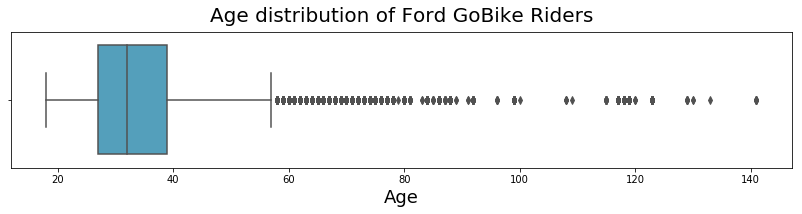

```python
plt.figure(figsize=(14,2.5))
sns.boxplot(x='member_age', data=ford,  palette="GnBu_d", orient='h')
plt.title("Age distribution of Ford GoBike Riders", fontsize=20, y=1.03)
plt.xlabel("Age", fontsize=18);
```

###### As we can see there are some outliers including some unrealistic values of age which is npt possible for a normal human, especially for riding a bike. Thus, let's consider riders below age 60 and find the mean age of the riders. We'll also plot distribution of number of rides with respect to various age groups and see people of which age group stands out.

```python
ford = ford[ford['member_age'] < 61]
```

```
Mean age of Riders: 33.5793321058
```

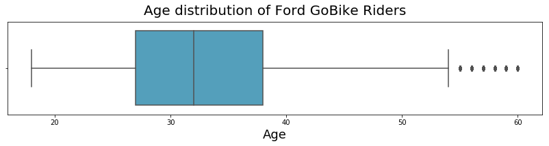

```python
plt.figure(figsize=(14,2.5))
sns.boxplot(x='member_age', data=ford, palette="GnBu_d", orient='h')
plt.title("Age distribution of Ford GoBike Riders", fontsize=20, y=1.03)
plt.xlabel("Age", fontsize=18);
print ('Mean age of Riders: {}'.format(ford['member_age'].mean()))
```

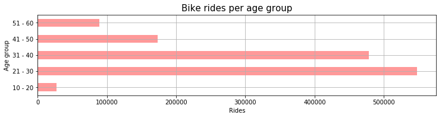

```python
ford['age_bins'] = ford['member_age'].apply(lambda x: '10 - 20' if 10<x<=20 else '21 - 30' if 20<x<=30
                                                  else '31 - 40' if 30<x<=40 else '41 - 50' if 40<x<=50
                                                  else '51 - 60' if 50<x<=60 else x)
trip_by_age = ford.groupby('age_bins').agg({'bike_id':'count'})
trip_by_age['bike_id'].plot(kind='barh', color='red', figsize=(12,2.5), alpha =0.4)
plt.title('Bike rides per age group', fontsize=15)
plt.ylabel('Age group')
plt.xlabel('Rides')
plt.grid()
```

###### Now, let us see how many of riders are Male, how many of them are Female or Others. We'll also explore the 'User Type' column. How many of them are Male, Female or Other?

```
Number of Male Riders:974946
Number of Female Riders:316283
Number of Riders in 'Other' Gender:24638
```

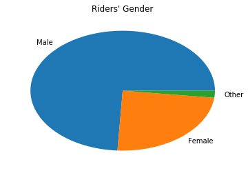

```python
ford['member_gender'].value_counts().plot(kind='pie')
plt.title("Riders' Gender");
plt.ylabel('')
print ('Number of Male Riders:{}'.format(len(ford[ford['member_gender']=='Male'])))
print ('Number of Female Riders:{}'.format(len(ford[ford['member_gender']=='Female'])))
print ("Number of Riders in 'Other' Gender:{}".format(len(ford[ford['member_gender']=='Other'])))
```

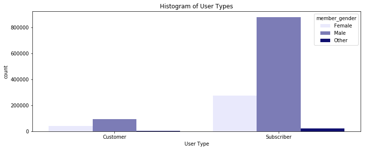

```python
plt.figure(figsize=(12,4.5))
sns.countplot(x = ford['user_type'], hue= ford['member_gender'], color = 'navy')
plt.xlabel('User Type')
plt.title('Histogram of User Types');
```

###### Hence, there are more number of Male riders than Female and 'Other'. And more number of Subscribers than Customers. Next, we'll see the distribution of trip duration. Do people opt for longer rides?

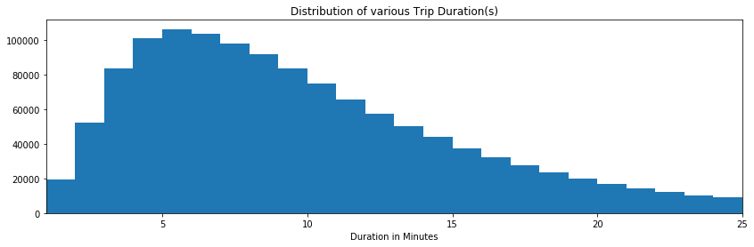

```python
plt.figure(figsize=(14,4))
binedges = np.arange(0, ford['duration_min'].max() + 1 , 1)
plt.hist(data = ford , x = 'duration_min' , bins = binedges)
plt.xlim(ford['duration_min'].min(),25)
plt.title('Distribution of various Trip Duration(s)')
plt.xlabel('Duration in Minutes')
```

###### For final step in univariate exploration we'll try to understand the daily trend in number of rides from Jan 2019 to July 2019. When does the number of rides go up? Is there any pattern?

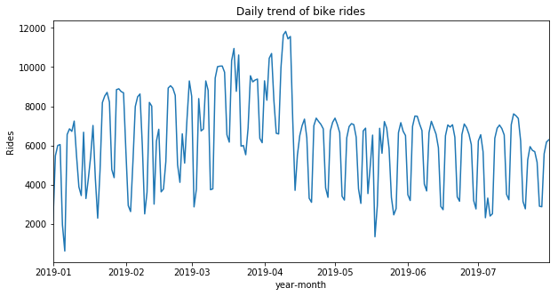

```python
ford.groupby(ford['start_time'].dt.date).agg('count')['bike_id'].plot(kind = 'line', figsize = [10, 5])
plt.title('Daily trend of bike rides')
plt.xlabel('year-month')
plt.ylabel('Rides');
```

```python
ford['start_time'].dt.month.value_counts()
```

```
3    239983
4    223751
1    178681
2    171617
5    169808
6    168985
7    163042
Name: start_time, dtype: int64
```

## Bivariate Visualization

###### As a part of bivariate visualization, we'll try to find out the ride duration for various gender and user types. We'll plot the monthly and weekly distribution of rides for all the genders and user types. We'll see how does business varies in a particular day. Finally we'll find out which are top 25 busiest start stations and end stations.

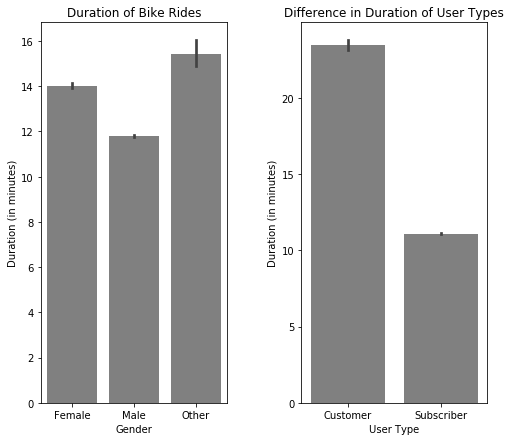

```python
plt.figure(figsize=(8,7))
grid = plt.GridSpec(1, 2,wspace=0.4, hspace=0.3)
plt.subplot(grid[0, 0])
sns.barplot(x = ford['member_gender'], y = ford['duration_min'], color = 'grey')
plt.title("Duration of Bike Rides")
plt.xlabel('Gender')
plt.ylabel('Duration (in minutes)');
plt.subplot(grid[0, 1])
sns.barplot(x = ford['user_type'], y = ford['duration_min'], color = 'grey')
plt.title('Difference in Duration of User Types')
plt.xlabel('User Type')
plt.ylabel('Duration (in minutes)');
```

###### We shall now draw monthly and weekly disribution of all the rides for all the genders and user types and see if we can conclude anything.

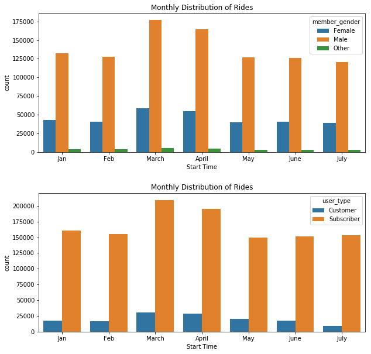

```python
plt.figure(figsize=(10,10))
grid = plt.GridSpec(2, 1,wspace=0.4, hspace=0.3)
plt.subplot(grid[0, 0])
x = sns.countplot(pd.DatetimeIndex(ford['start_time']).month, hue= ford['member_gender'])
months = ['Jan', 'Feb', 'March', 'April', 'May', 'June', 'July']
x.set_xticklabels(months, rotation = 0, size = 10)
plt.title('Monthly Distribution of Rides')
plt.xlabel('Start Time')
plt.subplot(grid[1, 0])
x = sns.countplot(pd.DatetimeIndex(ford['start_time']).month, hue= ford['user_type'])
x.set_xticklabels(months, rotation = 0, size = 10)
plt.title('Monthly Distribution of Rides')
plt.xlabel('Start Time')
```

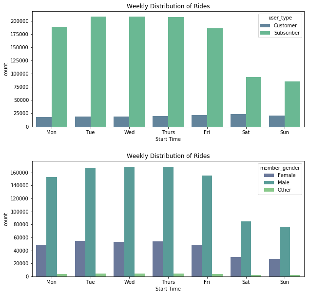

```python
plt.figure(figsize=(10,10))
grid = plt.GridSpec(2, 1,wspace=0.4, hspace=0.3)
plt.subplot(grid[0, 0])
x = sns.countplot(pd.DatetimeIndex(ford['start_time']).weekday, palette = "viridis", alpha = 0.8, hue = ford['user_type'])
day = ['Mon', 'Tue', 'Wed', 'Thurs', 'Fri', 'Sat', 'Sun']
x.set_xticklabels(day, rotation = 0, size = 10)
plt.title('Weekly Distribution of Rides')
plt.xlabel('Start Time')
plt.subplot(grid[1, 0])
x = sns.countplot(pd.DatetimeIndex(ford['start_time']).weekday, palette = "viridis", alpha = 0.8, hue = ford['member_gender'])
day = ['Mon', 'Tue', 'Wed', 'Thurs', 'Fri', 'Sat', 'Sun']
x.set_xticklabels(day, rotation = 0, size = 10)
plt.title('Weekly Distribution of Rides')
plt.xlabel('Start Time')
```

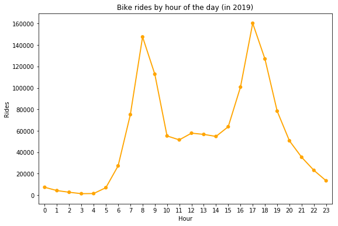

```python
ford['hour'] = ford['start_time'].dt.hour
trip_by_hour = ford.groupby('hour').agg({'bike_id':'count'}).reset_index()
plt.figure(figsize=(9,6))
sns.pointplot(x='hour', y='bike_id', scale=.7, color='orange', data=trip_by_hour)
plt.title('Bike rides by hour of the day (in 2019)')
plt.xlabel('Hour')
plt.ylabel('Rides');
```

###### Indeed, Business takes its peak during morning and evening office hours, and significantly goes down during night. It is assumable that younger people tend to opt for bikes more. This is a significant finding as we can introduce dynamic fare system which provides for lower fare when demand is low and vice-versa.

###### Finally, let's plot top 25 'Start Station' and 'End Station' for bike rides.

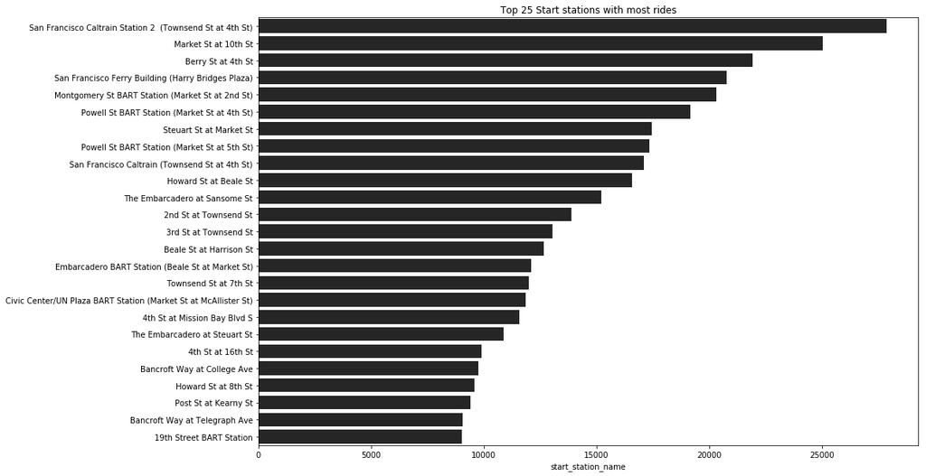

```python
plt.figure(figsize=(15,10))
data=ford.start_station_name.value_counts().head(25)
sns.barplot(y=data.index, x = data, orient='h',color='black',alpha = 0.85)
plt.title('Top 25 Start stations with most rides');
```

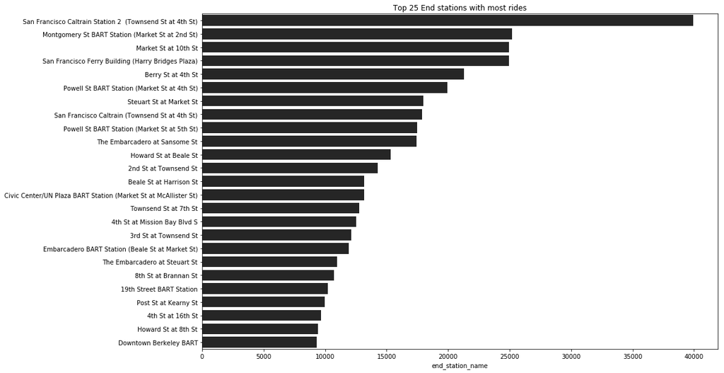

```python
plt.figure(figsize=(15,10))
data=ford.end_station_name.value_counts().head(25)
sns.barplot(y=data.index, x = data, orient='h',color='black',alpha = 0.85)
plt.title('Top 25 End stations with most rides');
```

###### I checked each variables one by one. (Average rides, daily and monthly trend of riders, age groups, genders, weekdays or weekends comparision, peak hours, user types with distances etc.) All these variables are important in order to understand the dataset and communicating the datafindings at the end of this project. We can talk about some of the variables. For example;

1. People use this service on weekdays more than weekends. Similarly, business peaks in March and April and slows down in June and July.
2. 8am and 5pm are the peak hours for this service. Also, people use this service when they are in lunch time as well.
3. Start station with most number of rides: 'San Francisco Caltrain Station 2(Townsend St at 4th St)', followed by 'Market St at 10th St' and 'Berry St at 4th St'
4. End station with most number of rides: 'San Francisco Caltrain Station 2 (Townsend St at 4th St)', followed by 'Montgomery St BART Station (Market St at 2nd St)' and 'Market St at 10th St'.
5. 'Female' and 'Other' riders tend to have longer ride duration.
6. Similarly, Though there are large number of Subscribers as compared to Customers, Customers tend to have a longer duration of rides.

### Multivariate Visualization

###### Finally, for multivariate visualisation, we'll draw a heatmap of correlation among various features of our dataset.

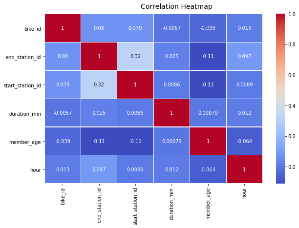

```python
f, ax = plt.subplots(figsize=(10, 6))
corr = ford.corr()
hm = sns.heatmap(corr, annot=True, ax=ax, cmap="coolwarm",linewidths=.05)
f.subplots_adjust(top=0.93)
t= f.suptitle('Correlation Heatmap', fontsize=14)
```